# Classification: HR against LR

How well does a single protein, gene-set score or module eigengene tell HR from LR? Nothing is fitted. For each feature the AUC (area under the ROC curve) is the chance that a random HR person has a higher value than a random LR person: 0.5 is a coin toss, 1 perfect separation with HR higher, 0 perfect separation with LR higher. The AUC equals the Mann-Whitney statistic W / (n_HR × n_LR) (Hanley and McNeil 1982), so its p comes from the Wilcoxon rank-sum test. This is single-feature discrimination, not a predictive classifier: no AUC is measured on people held out.

Five tasks: the T1, T2 and T3 levels, and the change over training (T2 − T1) and after the bout (T3 − T2), each for three feature types.

## Packages

pROC gives DeLong’s interval for the AUC; it is called with `::`.

```r
library(here)
library(dplyr)
library(tidyr)
library(purrr)
library(ggplot2)
source(here("00_Setup", "Shared_functions", "workbooks.R"))
source(here("00_Setup", "Shared_functions", "person_traits.R"))
inputs <- c(
  corrected = "01_Processing/03_Blood_Correction/c_data/blood_correction.rds",
  singscore = "01_Processing/05_Set_Scores/c_data/set_scores.rds",
  gene_sets = "01_Processing/04_Gene_Sets/c_data/gene_sets.rds",
  modules = "01_Processing/06_Module_Building/c_data/module_building.rds"
)
paths <- vapply(inputs, here, character(1))
stopifnot(file.exists(paths))
```

## Input

Rank tests take no covariate, so proteins come from the blood-corrected matrix. Set scores are singscores of the tested sets on that matrix; modules are the eigengenes.

```r
corrected <- readRDS(paths[["corrected"]])
catalog <- filter(readRDS(paths[["gene_sets"]])$set_catalog, qualifies)
modules <- readRDS(paths[["modules"]])
meta <- as_tibble(corrected$targets)
loaded <- load_features(corrected, readRDS(paths[["singscore"]])$scores, catalog, modules, meta)
features <- loaded$features
label_of <- loaded$label_of
collection_of <- loaded$collection_of
map(features, dim)
```

```
$proteins
[1] 2059   48

$sets
[1] 1422   48

$modules
[1] 10 48
```

## Tasks

`person_values()` (from `00_Setup/Shared_functions/person_traits.R`) returns one column per person: the value at a time point, or the change between two.

```r
task_values <- \(x) {
  list(
    Baseline_HRvLR = person_values(x, meta, "T1"),
    Trained_HRvLR = person_values(x, meta, "T2"),
    Acute_HRvLR = person_values(x, meta, "T3"),
    Training_change_HRvLR = person_values(x, meta, "T2", from = "T1"),
    Acute_change_HRvLR = person_values(x, meta, "T3", from = "T2")
  )
}
group_of <- set_names(meta$group, meta$subject)
table(group_of[unique(meta$subject)])
```

```
HR LR
 8  8
```

## AUC per feature and task

`discriminate()` takes one person-by-feature matrix and returns, per feature, the AUC, DeLong’s 95% interval, the Wilcoxon p and the people per group. At perfect separation DeLong’s variance is zero, so no interval is given there. `fdr` is Benjamini-Hochberg within feature type and task, and within collection for sets, since each collection is its own screen. With 8 against 8 people the smallest p the rank-sum test can reach is 2 / choose(16, 8) = 1.6^{-4}.

```r
discriminate <- function(x) {
  is_hr <- group_of[colnames(x)] == "HR"
  map(seq_len(nrow(x)), \(i) {
    hr <- x[i, is_hr]
    lr <- x[i, !is_hr]
    test <- wilcox.test(hr, lr)
    auc <- unname(test$statistic) / (length(hr) * length(lr))
    interval <- if (auc %in% c(0, 1)) {
      c(NA, NA)
    } else {
      pROC::roc(controls = lr, cases = hr, direction = "<", quiet = TRUE) |>
        pROC::ci.auc(method = "delong") |>
        as.numeric() |>
        _[c(1, 3)]
    }
    tibble(
      auc, auc_lower = interval[1], auc_upper = interval[2], p = test$p.value,
      n_hr = length(hr), n_lr = length(lr)
    )
  }) |>
    list_rbind() |>
    mutate(feature = rownames(x), .before = 1)
}
auc <- imap(features, \(x, type) {
  map(task_values(x), discriminate) |>
    list_rbind(names_to = "task") |>
    mutate(feature_type = type, .before = 1)
}) |>
  list_rbind() |>
  mutate(
    collection = unname(collection_of[feature]), label = unname(label_of[feature]),
    .after = feature
  ) |>
  mutate(fdr = p.adjust(p, "BH"), .by = c(feature_type, task, collection))
counts <- auc |>
  summarise(
    n_tested = n(), n_nominal = sum(p < 0.05), n_fdr_05 = sum(fdr < 0.05), min_p = min(p),
    best_auc = auc[which.max(abs(auc - 0.5))], .by = c(feature_type, task)
  )
counts
```

```
# A tibble: 15 × 7
   feature_type task                n_tested n_nominal n_fdr_05   min_p best_auc
   <chr>        <chr>                  <int>     <int>    <int>   <dbl>    <dbl>
 1 proteins     Baseline_HRvLR          2059        56        0 1.09e-3   0.0469
 2 proteins     Trained_HRvLR           2059       103        0 1.09e-3   0.0469
 3 proteins     Acute_HRvLR             2059       124        0 1.55e-4   0
 4 proteins     Training_change_HR…     2059        66        0 6.22e-4   0.0312
 5 proteins     Acute_change_HRvLR      2059       127        0 1.86e-3   0.938
 6 sets         Baseline_HRvLR          1422        24        0 6.99e-3   0.891
 7 sets         Trained_HRvLR           1422        18        0 2.95e-3   0.0781
 8 sets         Acute_HRvLR             1422       121        0 1.09e-3   0.953
 9 sets         Training_change_HR…     1422        30        1 6.22e-4   0.969
10 sets         Acute_change_HRvLR      1422        73        0 1.09e-3   0.0469
11 modules      Baseline_HRvLR            10         0        0 1.95e-1   0.297
12 modules      Trained_HRvLR             10         0        0 6.50e-2   0.219
13 modules      Acute_HRvLR               10         0        0 8.30e-2   0.234
14 modules      Training_change_HR…       10         0        0 1.30e-1   0.266
15 modules      Acute_change_HRvLR        10         2        0 3.79e-2   0.188
```

At p < 0.05 chance alone puts 5% of features below the line in every task.

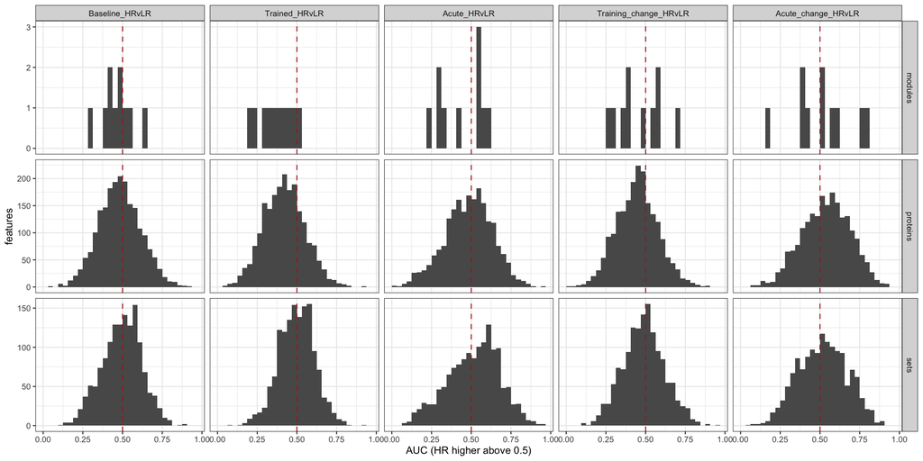

Figure 1: AUC per feature, by task and feature type. Dashed: 0.5.

```r
auc |>
  mutate(task = factor(task, names(task_values(features$modules)))) |>
  ggplot(aes(auc)) +
  geom_histogram(binwidth = 1 / 32, boundary = 0, fill = "grey35") +
  geom_vline(xintercept = 0.5, linetype = "dashed", colour = "firebrick") +
  facet_grid(feature_type ~ task, scales = "free_y") +
  labs(x = "AUC (HR higher above 0.5)", y = "features") +
  theme_bw(base_size = 8)
```

The strongest features per task: smallest p, ties broken by the AUC furthest from 0.5.

```r
top <- auc |>
  arrange(p, desc(abs(auc - 0.5))) |>
  slice_head(n = 3, by = c(feature_type, task)) |>
  mutate(rank = row_number(), .by = c(feature_type, task)) |>
  select(feature_type, task, rank, feature, collection, label, auc, auc_lower, auc_upper, p, fdr) |>
  arrange(feature_type, task, rank)
top
```

```
# A tibble: 45 × 11
   feature_type task     rank feature collection label   auc auc_lower auc_upper
   <chr>        <chr>   <int> <chr>   <chr>      <chr> <dbl>     <dbl>     <dbl>
 1 modules      Acute_…     1 red     <NA>       red   0.234   0           0.492
 2 modules      Acute_…     2 pink    <NA>       pink  0.297   0.00451     0.589
 3 modules      Acute_…     3 black   <NA>       black 0.312   0.00889     0.616
 4 modules      Acute_…     1 magenta <NA>       mage… 0.188   0           0.424
 5 modules      Acute_…     2 brown   <NA>       brown 0.797   0.552       1
 6 modules      Acute_…     3 yellow  <NA>       yell… 0.766   0.517       1
 7 modules      Baseli…     1 red     <NA>       red   0.297   0.0235      0.570
 8 modules      Baseli…     2 green   <NA>       green 0.656   0.347       0.965
 9 modules      Baseli…     3 magenta <NA>       mage… 0.406   0.101       0.712
10 modules      Traine…     1 yellow  <NA>       yell… 0.219   0           0.466
# ℹ 35 more rows
# ℹ 2 more variables: p <dbl>, fdr <dbl>
```

## Validation

```r
stopifnot(
  nrow(auc) == 5 * sum(map_int(features, nrow)), !anyNA(auc$p),
  all(auc$auc >= 0 & auc$auc <= 1), all(auc$fdr >= auc$p),
  all(auc$n_hr == 8 & auc$n_lr == 8)
)
```

## Summary

Across five tasks, 0 protein, 1 set and 0 module tests pass FDR < 0.05. The largest distance from 0.5 is an AUC of 0 (ACSL1, Acute_HRvLR).

## Save

`classification.rds` holds the AUC table for the figures.

```r
out <- here("02_HRvLR", "06_Classification", "c_data")
dir.create(out, showWarnings = FALSE)
saveRDS(list(auc = auc, counts = counts, top = top), file.path(out, "classification.rds"))
write_workbook(
  list(counts = counts, auc = arrange(auc, feature_type, task, collection, p), top = top),
  c(
    "Per feature type and task: tested, p < 0.05, FDR < 0.05, smallest p, AUC furthest from 0.5.",
    paste(
      "Per feature and task: AUC (HR above LR) with DeLong 95% CI, Wilcoxon p, people per group,",
      "FDR within feature type, task and collection."
    ),
    "Per feature type and task, the three features with the smallest p (Supplementary Figure 2)."
  ),
  file.path(out, "classification.xlsx"), inputs, paths
)
```